# Лабораторная работа №4

## Возвращаемся в root

- Возвращаемся в терминал root и удаляем пакеты lynx

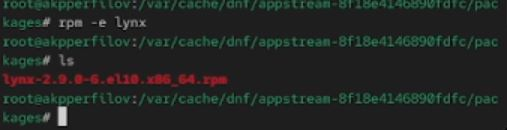

## Устанавливаем dnsmasq

- Устанавливаем пакеты dnsmasq

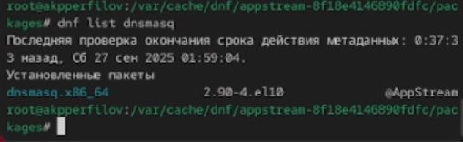

- Определяем расположение файла с помощью which dnsmasq

[figure not shown]

## Определяем пакет с dnsmasq

- Определяем к какому пакету принадлежит dnsmasq
- Получаем доп информацию о содержимом пакета

## Список всех файлов в пакете

- Получаем список всех файлов в пакете

[figure not shown]

## Выводим перечень и местоположение

- Выводи перечень файлов с документацией пакета

[figure not shown]

## Конфигурационные файлы пакета

- Выводи на экран перечень и месторасположение конфигурационных файлов пакета

[figure not shown]

## Ищем скрипты при установке

- Выводим на экран расположение и содержание скриптов

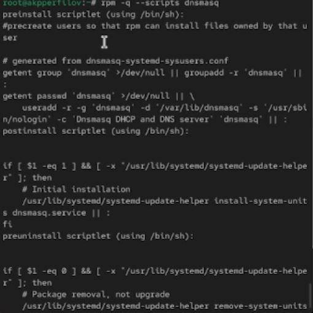

## Удаление пакета в учетной записи root

- Возвращаемся в терминал root и удаляем пакет rpm -e dnsmasq

## Вывод:

В ходе работы приобретены умения по работе с репозиториями и менеджарами пакетов а также поиску информации о них